# Trees, Boosted Trees, and Forests

# Evaluate the Predictive Performance using Test Data

- Compute Test Mean Square Error (Test MSE) and its standard error:

```r
yhat=predict(tree.boston,newdata=Boston[-train,])
boston.test=Boston[-train,"medv"]
summary(lm((yhat-boston.test)^2~1))$coef[1:2]
```

```
## [1] 38.063639  4.971637
```

# Pick the best tree by using the best “cp” parameter

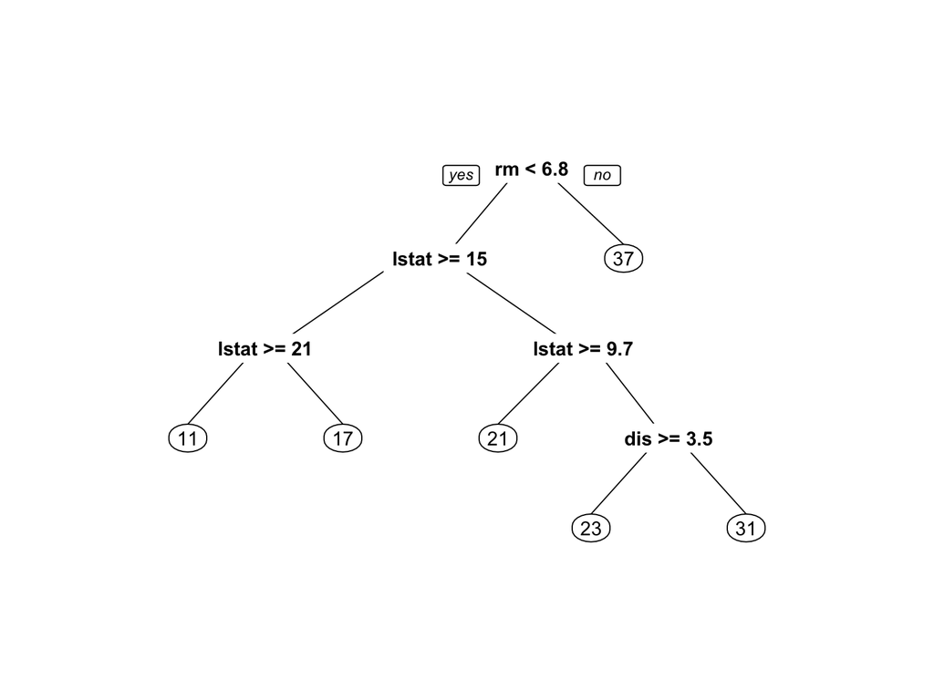

```r
fit.trees.Boston<- rpart(medv~.,data=Boston,subset=train)
bestcp<- fit.trees.Boston$cptable[which.min(trees$cptable[,"xerror"]),"CP"]
prunedtree.Boston <- prune(fit.trees.Boston,cp=bestcp)
prp(prunedtree.Boston)
```

# Evaluate the Predictive Performance

- Compute Test Mean Square Error (Test MSE) and its standard error:

```r
yhat=predict(prunedtree.Boston,newdata=Boston[-train,])
boston.test=Boston[-train,"medv"]
summary(lm((yhat-boston.test)^2~1))$coef[1:2]
```

```
## [1] 38.331810  4.969394
```

# Trees vs Linear Models | 1

- Reg tree fits linear functional forms:

$x \mapsto \sum_{m=1}^M c_m 1(x \in R_m)$

- The functional form is linear in parameters, but nonlinear in $x$.
- The dictionary of nonlinear transformations $1(x \in R_m), \quad m=1,...,M$ is found recursively by partitioning the space.

# Trees vs Linear Models | 2

- The linear regression models fit functional forms:

$x \mapsto \sum_{m=1}^M \beta_m B_m(x)$

- The dictionary of nonlinear transformations $B_m(x), \quad m=1,..., M$ is specified by the empirist. We’ve used polynomial transformations and interactions.

# Fit a “simple” linear model by rlasso

```r
library(hdm)
fmla<- medv~  (poly(lstat,2) + poly(rm, 2) + poly(dis,2) + poly(nox,2) + . ) ^2
rlasso.Boston<- rlasso(fmla,data=Boston,subset=train)
summary(rlasso.Boston,all=FALSE)
```

```
##
## Call:
## rlasso(formula = fmla, data = Boston, subset = train)
##
## Post-Lasso Estimation:  TRUE
##
## Total number of variables: 227
## Number of selected variables: 13
##
## Residuals:
##      Min       1Q   Median       3Q      Max
## -20.6551  -2.2742  -0.3399   1.6449  27.2013
##
##                    Estimate
## ptratio              -0.569
## poly(lstat, 2)1:rm   -7.047
## poly(lstat, 2)2:rm    5.389
## poly(rm, 2)1:zn       0.370
## poly(rm, 2)2:zn       0.251
## poly(rm, 2)1:rm       5.632
## poly(rm, 2)1:dis     -1.235
## poly(rm, 2)2:dis     11.378
## poly(rm, 2)1:black    0.017
## nox:lstat            -0.589
## rm:black              0.001
## dis:tax              -0.002
## tax:lstat             0.000
##
## Residual standard error: 3.996
## Multiple R-squared:  0.8112
## Adjusted R-squared:  0.8062
## Joint significance test:
##  the sup score statistic for joint significance test is 2.38e+06 with a p-value of 0.112
```

# Evaluate the Predictive Performance

- Compute Test Mean Square Error (Test MSE) and its standard error:

```r
yhat.lasso=predict(rlasso.Boston,newdata=Boston[-train,])
boston.test=Boston[-train,"medv"]
summary(lm((yhat.lasso-boston.test)^2~1))$coef[1:2]
```

```
## [1] 16.096737  3.022929
```

# Bagging

- Bagging: Bootstrap aggregation or bagging averages
- Training data $Z=\{(x_1,y_1),\ldots,(x_n,y_n)\}$. Fit a model to $Z$ and obtain $x \mapsto \hat{f}(x)$
- Idea: obtain predictions over many bootstrap samples and average them

– $Z^{*b}, b=1,\ldots,B$ bootstrap samples

– For each $b$ fit model a model to $Z^{*b}$ to get $x \mapsto \hat{f}^{*,b}(x)$

– $\hat{f}_{bag}(x)=1/B \sum_{b=1}^B \hat{f}^{*,b}(x)$

# Bagging

- This is seemingly crazy at a first sight… but the idea is that if $Z^{*b}$ were independent draws from the true data generating process, averaging over many independent prediction rules would be perfectly sensible.
- Well suited for high-variance and low-bias procedures; so we should be bagging trees that are relatively deep.
- Main Application: regression trees
- Bagged Trees is particular version of Random Forest.

# Example of Bagging on Trees

```r
library(randomForest)
set.seed(1)
bag.boston=randomForest(medv~.,data=Boston,subset=train, mtry=13, ntree=5000)
# mtry=13 =equal to the number of variables, which implements bagging trees
```

- Compute Test Mean Square Error (Test MSE) and its standard error:

```r
yhat= predict(bag.boston,newdata=Boston[-train,])
summary(lm((yhat-boston.test)^2~1))$coef[1:2]
```

```
## [1] 14.604152  2.101072
```

# Random Forests

- Introduced by Breiman (2001)
- Very powerful, all-purposes method with many applications
- Modified version of bagging
- Idea: Building a large collection of de-correlated trees and then average them (Breiman, 2001)

# Random Forests | Procedure

- Bootstrap samples $1,\ldots,B$
- Build trees and before each split, select $m \leq p$ – typically $m < p$ – of the input variables at random as candidates for splitting, for example, $m=\sqrt{p}$ and $m=1$.
- This induces the “decorrelation” of trees, since it precludes the “strong” predictors imposing too much structure on the trunk of the tree.
- Aggregation: $\hat{f}_{rf}(x) = \frac{1}{B} \sum_{b=1}^B \hat f^{*,b}_h(x)$ Here $h$ is the tuning parameter, which could include $h = m$ and other parameters of the tree-building algorithms.

# Example of Random Forest with m=3

```r
library(randomForest)
set.seed(1)
bag.boston=randomForest(medv~.,data=Boston,subset=train, mtry=3, ntree=5000)
# mtry=3 =equal to the number of variables which we consider splitting, which implements bagging trees
yhat.rf = predict(bag.boston,newdata=Boston[-train,])
```

- Compute Test Mean Square Error (Test MSE) and its standard error:

```r
summary(lm((yhat.rf-boston.test)^2~1))$coef[1:2]
```

```
## [1] 15.477009  2.324539
```

# Boosting

- The idea of boosting is that of a recursive fitting:

We fit a tree, then take the residuals and fit another tree to the residuals, etc. This implicitly defines a prediction rule.

- In order to avoid overfitting we can regularize the procedure in many different ways:
- By considering how many steps to make
- By only partially updating the fit.

# Boosting | Algorithm

– 1. Initialize the prediction rule $x \mapsto \hat f(x) = 0$ and $r_i = y_i, i=1,...,n$

– 2. For $j=1,...,J$

– (a) fit a tree of depth $d$, $x \mapsto \hat f^j(x)$ to the data $(x_i, r_i)_{i=1}^n$;

– (b) update the residuals $r_i = r_i - \lambda \hat f^j(x_i)$

– 3. Ouput the boosted model

$x \mapsto \hat f(x) = \sum_{j=1}^J \lambda \hat f^j(x).$

# Boosting Algorithm Parameters

Parameters:

- $\lambda \in (0,1)$ - anti-shrinkage parameter; $\lambda=1$ no shrinkage; $\lambda$ small forces only small updates. $J$ - total number of iterations;
- Either of these could be picked by looking at test errors or cross-validation.

Interpretations:

- Can be interpreted as the “gradient descent” algorithm from numerical optimization.

# Boosting: an example in R

```r
options(warn=-1,message=-1)
library(gbm)
set.seed(1)
boost.boston=gbm(medv~.,data=Boston[train,],distribution= "gaussian",n.trees=5000, interaction.depth=4)
yhat.boost =predict(boost.boston,newdata=Boston[-train,],n.trees=5000)
```

- Compute Test Mean Square Error (Test MSE) and its standard error:

```r
summary(lm((yhat.boost-boston.test)^2~1))$coef[1:2]
```

```
## [1] 17.828743  2.266153
```

# Boosting: example in R

```r
library(gbm)
set.seed(1)
boost.boston=gbm(medv~.,data=Boston[train,],distribution= "gaussian",n.trees=5000, interaction.depth=2)
yhat =predict(boost.boston,newdata=Boston[-train,],n.trees=5000)
```

- Compute Test Mean Square Error (Test MSE) and its standard error:

```r
summary(lm((yhat-boston.test)^2~1))$coef[1:2]
```

```
## [1] 18.721235  2.467928
```

# Combinining Predictions/ Aggregations/ Ensemble Learning |Introduction

- Idea: To build a prediction model by combing the strengths of a collection of simpler base models.
- We consider functions of the form $f(x) = \sum_{k=1}^K \alpha_k f_k(x)$ where $f_k$’s denote prediction rules, including possibly a constant.
- We can build prediction rules from the training data. We can figure out a good way to combine them using the test or validation data.

# Combinining Predictions/ Aggregations/ Ensemble Learning |Introduction

- If $K$ is small, we can figure out the optimal linear combo of the rules using test data $Test$, by simply … running least squares. $\min_{(\alpha_k)_{k=1}^K} \sum_{i \in Test} (y_i - \sum_{k=1}^K \alpha_k f_k(x))^2.$
- If $K$ is large, can do Lasso aggregation instead: $\min_{(\alpha_k)_{k=1}^K} \sum_{i \in Test} (y_i - \sum_{k=1}^K \alpha_k f_k(x))^2 + \lambda \sum_{k=1}^K | \alpha_k|$

# Combinining Predictions/ Aggregations/ Ensemble Learning |Example

- Least squares aggregation:

```r
summary(lm(boston.test~ -1+ yhat.rf+yhat.boost+yhat.lasso))
```

```
##
## Call:
## lm(formula = boston.test ~ -1 + yhat.rf + yhat.boost + yhat.lasso)
##
## Residuals:
##      Min       1Q   Median       3Q      Max
## -16.6177  -2.1385  -0.6409   1.1450  23.4641
##
## Coefficients:
##            Estimate Std. Error t value Pr(>|t|)
## yhat.rf     0.48911    0.09379   5.215 3.04e-07 ***
## yhat.boost  0.05936    0.08948   0.663    0.507
## yhat.lasso  0.45496    0.06230   7.303 1.69e-12 ***
## ---
## Signif. codes:  0 '***' 0.001 '**' 0.01 '*' 0.05 '.' 0.1 ' ' 1
##
## Residual standard error: 3.655 on 377 degrees of freedom
## Multiple R-squared:  0.9778, Adjusted R-squared:  0.9776
## F-statistic:  5532 on 3 and 377 DF,  p-value: < 2.2e-16
```

# Combinining Predictions/ Aggregations/ Ensemble Learning |Example

- Lasso aggregation:

```r
summary(rlasso(boston.test~ -1+ yhat.rf+yhat.boost+yhat.lasso, post=FALSE))
```

```
##
## Call:
## rlasso(formula = boston.test ~ -1 + yhat.rf + yhat.boost + yhat.lasso,
##     post = FALSE)
##
## Post-Lasso Estimation:  FALSE
##
## Total number of variables: 3
## Number of selected variables: 2
##
## Residuals:
##      Min       1Q   Median       3Q      Max
## -14.0808  -1.8244  -0.4197   1.4152  21.3002
##
##            Estimate
## yhat.rf       0.867
## yhat.boost    0.000
## yhat.lasso    0.237
##
## Residual standard error: 3.555
## Multiple R-squared:  0.8523
## Adjusted R-squared:  0.8515
## Joint significance test:
##  the sup score statistic for joint significance test is  1431 with a p-value of     0
```

# Summary and Conclusions

- We’ve seen a slightly more systematic approach to building trees, and ways to improve them by aggregation.
- Bootstrap samples lead to different trees, and averaging them seems like a good idea and works well. Averaging over bootstrap samples is called bagging!
- Random forests actually try to average over decorrelated “deep” trees; decorrelation is achieved by choosing randomly on which variables to split during the recursion. This results in many “different” trees.
- Boosting uses recursive fitting of residuals by a sequence of “shallow” tree models.